# Statistical Analysis of the Fruit Survey

Master Thesis of “Conservación y Biodiversidad en Áreas Tropicales” - RJB-CSIC.

Guillem Pocull Bellés

04 setembre, 2020

## 0. Install and load packages

```r
library('ggplot2')
library('lattice')
library('purrr')
library('dplyr')
library('carData')
library('ggpubr')
library('readr')
library('cowplot')
library('tinytex')
library('tidyverse')
library('caret')
```

## 1. Envelopes

### 1.0. Preparation

#### 1.0.1. Metadata

- Envelope_ID: identification of the envelope with 2 fruits from the plant.
- Flank: colour/place of the flowers of the plant.
- Fruits: total number of fruits from the plant.
- Holes: number of fruits with a hole from the plant.
- Damage: percentage of fruits with a hole respectively from the total (holes/fruits)
- ***: the fact that there is significant differences between these flanks, it doesn’t mean there are significant differences between subspecies ‘pseudomajus’ (magenta) and ‘striatum’ (yellow). If we say so, we are commiting pseudoreplication in this particularly case.

#### 1.0.2. Open Data

```r
envelopes <- read_delim("Data_Envelopes.csv",";", escape_double = FALSE,
                             col_types = cols(Envelope_ID = col_character()), trim_ws = TRUE)

View(envelopes)
str(envelopes)
```

```
## tibble [83 x 5] (S3: spec_tbl_df/tbl_df/tbl/data.frame)
##  $ Envelope_ID: chr [1:83] "1" "2" "3" "4" ...
##  $ Flank      : chr [1:83] "Magenta" "Magenta" "Magenta" "Magenta" ...
##  $ Fruits     : num [1:83] 2 8 6 10 7 17 2 6 6 5 ...
##  $ Holes      : num [1:83] 1 1 3 2 2 2 1 3 2 1 ...
##  $ Damage     : num [1:83] 0.5 0.125 0.5 0.2 0.286 ...
##  - attr(*, "spec")=
##   .. cols(
##   ..   Envelope_ID = col_character(),
##   ..   Flank = col_character(),
##   ..   Fruits = col_double(),
##   ..   Holes = col_double(),
##   ..   Damage = col_double()
##   .. )
```

### 1.1. Modify and visualize datasheets

Transform data to ‘data.frame’

```r
envelopes_df <- as.data.frame(envelopes)
View(envelopes_df)
```

Preparation of the Summary Table

```r
sum_fruits <- as.data.frame(group_by(envelopes_df, Flank) %>%
                           summarise(
                             count = n(),
                             mean = mean(Fruits, na.rm = TRUE),
                             sd = sd(Fruits, na.rm = TRUE)))

sum_holes <- as.data.frame(group_by(envelopes_df, Flank) %>%
                           summarise(
                             count = n(),
                             mean = mean(Holes, na.rm = TRUE),
                             sd = sd(Holes, na.rm = TRUE)))

sum_damage <- as.data.frame(group_by(envelopes_df, Flank) %>%
                           summarise(
                             count = n(),
                             mean = mean(Damage, na.rm = TRUE),
                             sd = sd(Damage, na.rm = TRUE)))

summarise_rbind <- rbind(sum_fruits,sum_holes,sum_damage)
envelopes_summarise <- data.frame(Type=c("fruits", "fruits", "holes", "holes", "damage", "damage"),summarise_rbind)
```

Summary of the mean and standard deviation of fruits, holes and damage

```r
envelopes_summarise
```

| Type | Flank | count | mean | sd |
| --- | --- | --- | --- | --- |
| fruits | Magenta | 40 | 6.4250000 | 4.5847434 |
| fruits | Yellow | 43 | 16.7674419 | 13.3181530 |
| holes | Magenta | 40 | 2.1750000 | 1.2585604 |
| holes | Yellow | 43 | 4.2325581 | 3.5445277 |
| damage | Magenta | 40 | 0.3948459 | 0.1749141 |
| damage | Yellow | 43 | 0.3037595 | 0.1972697 |

We save the summary to ‘.csv’

```r
write.csv(envelopes_summarise, "C:/Users/guill/Desktop/TFM/R/Script_Fruits/envelopes_summarise.csv",
          row.names=F, fileEncoding = "UTF-8")
```

### 1.2. Statistics

#### 1.2.1. Shapiro Test

Shapiro Test of all data to analyze the normality of data

```r
shapiro.test(envelopes_df$Fruits) # for fruits:  p-value < 0.001
```

```
##
##  Shapiro-Wilk normality test
##
## data:  envelopes_df$Fruits
## W = 0.7566, p-value = 2.067e-10
```

```r
shapiro.test(envelopes_df$Damage) # for damage:  p-value = 0.0017
```

```
##
##  Shapiro-Wilk normality test
##
## data:  envelopes_df$Damage
## W = 0.94613, p-value = 0.001654
```

```r
# Any of the variables has normality.
```

Shapiro Test of each magenta or yellow data

```r
envelopes_magenta <- envelopes_df %>% filter(Flank == "Magenta")
View(envelopes_magenta)

envelopes_yellow <- envelopes_df %>% filter(Flank == "Yellow")
View(envelopes_yellow)

shapiro.test(envelopes_magenta$Fruits) # for fruits:  p-value < 0.001
```

```
##
##  Shapiro-Wilk normality test
##
## data:  envelopes_magenta$Fruits
## W = 0.75185, p-value = 7.735e-07
```

```r
shapiro.test(envelopes_magenta$Damage) # for damage:  p-value =0.189
```

```
##
##  Shapiro-Wilk normality test
##
## data:  envelopes_magenta$Damage
## W = 0.96155, p-value = 0.1891
```

```r
shapiro.test(envelopes_yellow$Fruits)  # for fruits:  p-value < 0.001
```

```
##
##  Shapiro-Wilk normality test
##
## data:  envelopes_yellow$Fruits
## W = 0.85966, p-value = 9.221e-05
```

```r
shapiro.test(envelopes_yellow$Damage)  # for damage:  p-value < 0.001
```

```
##
##  Shapiro-Wilk normality test
##
## data:  envelopes_yellow$Damage
## W = 0.89077, p-value = 0.0006645
```

```r
# Only 'Damage' for the magenta has data with normality.
```

Visualize the normality curve

- Fruits

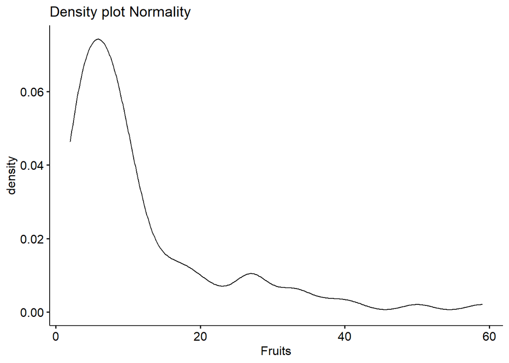

```r
ggdensity(envelopes_df$Fruits,
          main = "Density plot Normality",
          xlab = "Fruits")
```

```r
# In the graphic we can visualize the no-normality of the data
```

- Damage: because it has certain normality.

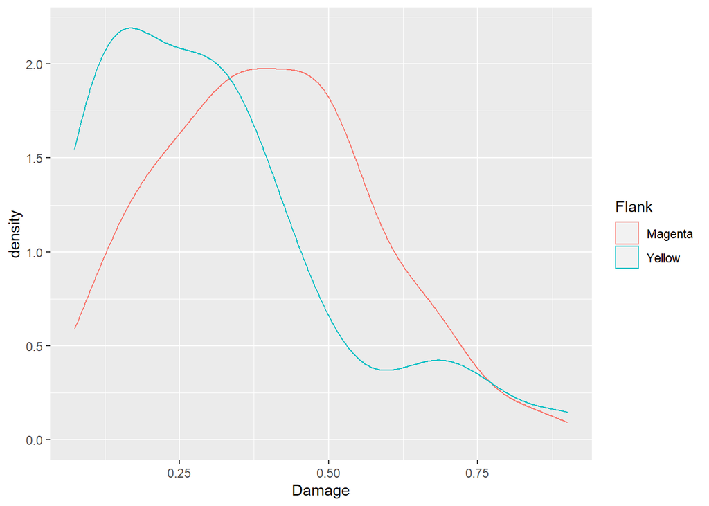

```r
ggplot(envelopes_df, aes(x=Damage, colour=Flank)) + geom_density()
```

```r
# We can visualize Magenta Flank has data with normality.
```